# Project1-Muthyam

2022-09-17

## 1. Vegashotel Dataset

**1. Explore the overall structure of the dataset using str(). When you read the data, set StringAsFactors=True to let R convert String variables to factors.**

```r
Vegashotel<-read.csv("C:/Users/mmoku2/Downloads/vegashotels-1.csv",sep = ";", stringsAsFactors = TRUE)
str(Vegashotel)
```

```
## 'data.frame':    504 obs. of  20 variables:
##  $ User.country     : Factor w/ 48 levels "Australia","Belgium",..: 48 48 48 46 4 4 46 48 18 4 ...
##  $ Nr..reviews      : int  11 119 36 14 5 31 45 2 24 12 ...
##  $ Nr..hotel.reviews: int  4 21 9 7 5 8 12 1 3 7 ...
##  $ Helpful.votes    : int  13 75 25 14 2 27 46 4 8 11 ...
##  $ Score            : int  5 3 5 4 4 3 4 4 4 3 ...
##  $ Period.of.stay   : Factor w/ 4 levels "Dec-Feb","Jun-Aug",..: 1 1 3 3 3 3 3 3 3 3 ...
##  $ Traveler.type    : Factor w/ 5 levels "Business","Couples",..: 4 1 3 4 5 2 2 3 4 3 ...
##  $ Pool             : Factor w/ 2 levels "NO","YES": 1 1 1 1 1 1 1 1 1 1 ...
##  $ Gym              : Factor w/ 2 levels "NO","YES": 2 2 2 2 2 2 2 2 2 2 ...
##  $ Tennis.court     : Factor w/ 2 levels "NO","YES": 1 1 1 1 1 1 1 1 1 1 ...
##  $ Spa              : Factor w/ 2 levels "NO","YES": 1 1 1 1 1 1 1 1 1 1 ...
##  $ Casino           : Factor w/ 2 levels "NO","YES": 2 2 2 2 2 2 2 2 2 2 ...
##  $ Free.internet    : Factor w/ 2 levels "NO","YES": 2 2 2 2 2 2 2 2 2 2 ...
##  $ Hotel.name       : Factor w/ 21 levels "Bellagio Las Vegas",..: 3 3 3 3 3 3 3 3 3 3 ...
##  $ Hotel.stars      : Factor w/ 5 levels "3","3,5","4",..: 1 1 1 1 1 1 1 1 1 1 ...
##  $ Nr..rooms        : int  3773 3773 3773 3773 3773 3773 3773 3773 3773 3773 ...
##  $ User.continent   : Factor w/ 6 levels "Africa","Asia",..: 4 4 4 3 4 4 3 4 2 4 ...
##  $ Member.years     : int  9 3 2 6 7 2 4 0 3 5 ...
##  $ Review.month     : Factor w/ 12 levels "April","August",..: 5 5 4 4 8 8 1 1 9 9 ...
##  $ Review.weekday   : Factor w/ 7 levels "Friday","Monday",..: 5 1 3 1 6 6 1 6 3 6 ...
```

- by seeing the above structure we can say that there are 6 numerical and 14 categorical variables.

**2 Does any of the variables have missing values?**

```r
a<-is.na(Vegashotel)
sum(is.na(a))
```

```
## [1] 0
```

- there is no missing values.

**3)Draw a histogram of the score variable. Interpret the histogram.**

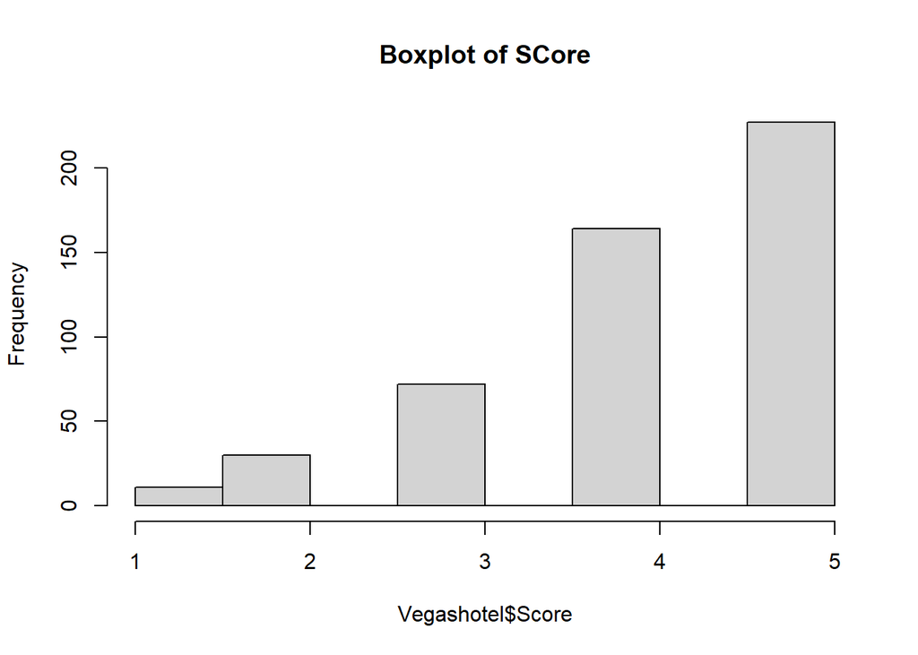

```r
hist(Vegashotel$Score, main="Boxplot of SCore" ,Xlabs="Score")
```

- by seeing we can say that 5 has highest frequency and lowest frequency for 1

**4) Find the mode of “Score”**

```r
temp<-table(Vegashotel$Score)
x<-temp==max(temp)
names(which(x))
```

```
## [1] "5"
```

- mode of score is 5

**5) Use the “quantile” function to get the quantiles for score. What is the median of score?**

```r
quantile(Vegashotel$Score)
```

```
##   0%  25%  50%  75% 100%
##    1    4    4    5    5
```

```r
median(Vegashotel$Score)
```

```
## [1] 4
```

```r
summary(Vegashotel$Score)
```

```
##    Min. 1st Qu.  Median    Mean 3rd Qu.    Max.
##   1.000   4.000   4.000   4.123   5.000   5.000
```

- by using both median and summary functions we got median of score is 4

**6)Use the ifelse function (You can get help on the syntax of this function in R by typing ?ifelse) to create a factor variable “sentiment” which takes the value “positive” if score is 4 or 5 and “negative” otherwise. You can use the method “factor” to create a factor from a character vector. Take a summary of “sentiment” to make sure that the frequencies of “positive” and “negative” categories are consistent with the frequency of the values in Score (e.g., the frequency for the “positive” sentiment should be equal to the combined frequency of 4 and 5 for the Score)**

```r
Vegashotel$sentiment<-ifelse(Vegashotel$Score>=4,"positive","negative")

TempSentiment<-table(Vegashotel$sentiment)
TempSentiment
```

```
##
## negative positive
##      113      391
```

```r
TempScore<-table(Vegashotel$Score)
Pos_Fereq<-TempScore[[4]]+TempScore[[5]]
Pos_Fereq
```

```
## [1] 391
```

```r
Neg_Fereq<-sum(TempScore)-Pos_Fereq
Neg_Fereq
```

```
## [1] 113
```

- By above we can say that
- Pos_Fereq is sum of ‘4’ and ‘5’ which is equal to Positive
- Neq_Fereq is sum of ‘3’ and ‘2’ and ‘1’ which is equal to Negative.

**7)Use appropriate statistical test and plots to determine if sentiment is associated with any of the variables: “Pool”, “Gym”,“Free.Internet”, “Period.of.Stay”, “traverler.type”“, and”hotel.stars” (Assume the significance level alpha=0.01). Interpret the plots and explain which of these variables are associated with sentiment?**

```r
library(gmodels)
CrossTable(Vegashotel$sentiment,Vegashotel$Pool,chisq=TRUE,)
```

```
##
##
##    Cell Contents
## |-------------------------|
## |                       N |
## | Chi-square contribution |
## |           N / Row Total |
## |           N / Col Total |
## |         N / Table Total |
## |-------------------------|
##
##
## Total Observations in Table:  504
##
##
##                      | Vegashotel$Pool
## Vegashotel$sentiment |        NO |       YES | Row Total |
## ---------------------|-----------|-----------|-----------|
##             negative |        13 |       100 |       113 |
##                      |    10.788 |     0.539 |           |
##                      |     0.115 |     0.885 |     0.224 |
##                      |     0.542 |     0.208 |           |
##                      |     0.026 |     0.198 |           |
## ---------------------|-----------|-----------|-----------|
##             positive |        11 |       380 |       391 |
##                      |     3.118 |     0.156 |           |
##                      |     0.028 |     0.972 |     0.776 |
##                      |     0.458 |     0.792 |           |
##                      |     0.022 |     0.754 |           |
## ---------------------|-----------|-----------|-----------|
##         Column Total |        24 |       480 |       504 |
##                      |     0.048 |     0.952 |           |
## ---------------------|-----------|-----------|-----------|
##
##
## Statistics for All Table Factors
##
##
## Pearson's Chi-squared test
## ------------------------------------------------------------
## Chi^2 =  14.60109     d.f. =  1     p =  0.0001328376
##
## Pearson's Chi-squared test with Yates' continuity correction
## ------------------------------------------------------------
## Chi^2 =  12.74758     d.f. =  1     p =  0.0003564702
##
##
```

*p value is less than significance, so rejecting the null hypothesis that sentiment and pool are independent. so we can say that both sentiment and Pool are associated.

```r
library(gmodels)
CrossTable(Vegashotel$sentiment,Vegashotel$Gym, chisq=TRUE)
```

```
##
##
##    Cell Contents
## |-------------------------|
## |                       N |
## | Chi-square contribution |
## |           N / Row Total |
## |           N / Col Total |
## |         N / Table Total |
## |-------------------------|
##
##
## Total Observations in Table:  504
##
##
##                      | Vegashotel$Gym
## Vegashotel$sentiment |        NO |       YES | Row Total |
## ---------------------|-----------|-----------|-----------|
##             negative |         6 |       107 |       113 |
##                      |     0.071 |     0.004 |           |
##                      |     0.053 |     0.947 |     0.224 |
##                      |     0.250 |     0.223 |           |
##                      |     0.012 |     0.212 |           |
## ---------------------|-----------|-----------|-----------|
##             positive |        18 |       373 |       391 |
##                      |     0.021 |     0.001 |           |
##                      |     0.046 |     0.954 |     0.776 |
##                      |     0.750 |     0.777 |           |
##                      |     0.036 |     0.740 |           |
## ---------------------|-----------|-----------|-----------|
##         Column Total |        24 |       480 |       504 |
##                      |     0.048 |     0.952 |           |
## ---------------------|-----------|-----------|-----------|
##
##
## Statistics for All Table Factors
##
##
## Pearson's Chi-squared test
## ------------------------------------------------------------
## Chi^2 =  0.09639001     d.f. =  1     p =  0.7562055
##
## Pearson's Chi-squared test with Yates' continuity correction
## ------------------------------------------------------------
## Chi^2 =  0.003564719     d.f. =  1     p =  0.9523904
##
##
```

- Here p is more than Alpha value , so both are not associated.

```r
library(gmodels)
CrossTable(Vegashotel$sentiment,Vegashotel$Free.internet, chisq=TRUE)
```

```
##
##
##    Cell Contents
## |-------------------------|
## |                       N |
## | Chi-square contribution |
## |           N / Row Total |
## |           N / Col Total |
## |         N / Table Total |
## |-------------------------|
##
##
## Total Observations in Table:  504
##
##
##                      | Vegashotel$Free.internet
## Vegashotel$sentiment |        NO |       YES | Row Total |
## ---------------------|-----------|-----------|-----------|
##             negative |        12 |       101 |       113 |
##                      |     8.142 |     0.407 |           |
##                      |     0.106 |     0.894 |     0.224 |
##                      |     0.500 |     0.210 |           |
##                      |     0.024 |     0.200 |           |
## ---------------------|-----------|-----------|-----------|
##             positive |        12 |       379 |       391 |
##                      |     2.353 |     0.118 |           |
##                      |     0.031 |     0.969 |     0.776 |
##                      |     0.500 |     0.790 |           |
##                      |     0.024 |     0.752 |           |
## ---------------------|-----------|-----------|-----------|
##         Column Total |        24 |       480 |       504 |
##                      |     0.048 |     0.952 |           |
## ---------------------|-----------|-----------|-----------|
##
##
## Statistics for All Table Factors
##
##
## Pearson's Chi-squared test
## ------------------------------------------------------------
## Chi^2 =  11.01983     d.f. =  1     p =  0.0009014228
##
## Pearson's Chi-squared test with Yates' continuity correction
## ------------------------------------------------------------
## Chi^2 =  9.417846     d.f. =  1     p =  0.002148838
##
##
```

- Here p is less than Alpha value , so both are associated.

```r
library(gmodels)
CrossTable(Vegashotel$sentiment,Vegashotel$Period.of.stay, chisq=TRUE)
```

```
##
##
##    Cell Contents
## |-------------------------|
## |                       N |
## | Chi-square contribution |
## |           N / Row Total |
## |           N / Col Total |
## |         N / Table Total |
## |-------------------------|
##
##
## Total Observations in Table:  504
##
##
##                      | Vegashotel$Period.of.stay
## Vegashotel$sentiment |   Dec-Feb |   Jun-Aug |   Mar-May |   Sep-Nov | Row Total |
## ---------------------|-----------|-----------|-----------|-----------|-----------|
##             negative |        24 |        24 |        33 |        32 |       113 |
##                      |     0.520 |     0.639 |     0.645 |     0.498 |           |
##                      |     0.212 |     0.212 |     0.292 |     0.283 |     0.224 |
##                      |     0.194 |     0.190 |     0.258 |     0.254 |           |
##                      |     0.048 |     0.048 |     0.065 |     0.063 |           |
## ---------------------|-----------|-----------|-----------|-----------|-----------|
##             positive |       100 |       102 |        95 |        94 |       391 |
##                      |     0.150 |     0.185 |     0.186 |     0.144 |           |
##                      |     0.256 |     0.261 |     0.243 |     0.240 |     0.776 |
##                      |     0.806 |     0.810 |     0.742 |     0.746 |           |
##                      |     0.198 |     0.202 |     0.188 |     0.187 |           |
## ---------------------|-----------|-----------|-----------|-----------|-----------|
##         Column Total |       124 |       126 |       128 |       126 |       504 |
##                      |     0.246 |     0.250 |     0.254 |     0.250 |           |
## ---------------------|-----------|-----------|-----------|-----------|-----------|
##
##
## Statistics for All Table Factors
##
##
## Pearson's Chi-squared test
## ------------------------------------------------------------
## Chi^2 =  2.966974     d.f. =  3     p =  0.3967453
##
##
##
```

- Here p is more than Alpha value , so both are not associated.

```r
library(gmodels)
CrossTable(Vegashotel$sentiment,Vegashotel$Traveler.type, chisq=TRUE)
```

```
##
##
##    Cell Contents
## |-------------------------|
## |                       N |
## | Chi-square contribution |
## |           N / Row Total |
## |           N / Col Total |
## |         N / Table Total |
## |-------------------------|
##
##
## Total Observations in Table:  504
##
##
##                      | Vegashotel$Traveler.type
## Vegashotel$sentiment |  Business |   Couples |  Families |   Friends |      Solo | Row Total |
## ---------------------|-----------|-----------|-----------|-----------|-----------|-----------|
##             negative |        21 |        39 |        33 |        14 |         6 |       113 |
##                      |     1.172 |     1.681 |     2.818 |     1.046 |     0.071 |           |
##                      |     0.186 |     0.345 |     0.292 |     0.124 |     0.053 |     0.224 |
##                      |     0.284 |     0.182 |     0.300 |     0.171 |     0.250 |           |
##                      |     0.042 |     0.077 |     0.065 |     0.028 |     0.012 |           |
## ---------------------|-----------|-----------|-----------|-----------|-----------|-----------|
##             positive |        53 |       175 |        77 |        68 |        18 |       391 |
##                      |     0.339 |     0.486 |     0.815 |     0.302 |     0.021 |           |
##                      |     0.136 |     0.448 |     0.197 |     0.174 |     0.046 |     0.776 |
##                      |     0.716 |     0.818 |     0.700 |     0.829 |     0.750 |           |
##                      |     0.105 |     0.347 |     0.153 |     0.135 |     0.036 |           |
## ---------------------|-----------|-----------|-----------|-----------|-----------|-----------|
##         Column Total |        74 |       214 |       110 |        82 |        24 |       504 |
##                      |     0.147 |     0.425 |     0.218 |     0.163 |     0.048 |           |
## ---------------------|-----------|-----------|-----------|-----------|-----------|-----------|
##
##
## Statistics for All Table Factors
##
##
## Pearson's Chi-squared test
## ------------------------------------------------------------
## Chi^2 =  8.749461     d.f. =  4     p =  0.06767611
##
##
##
```

- Here p is more than Alpha value , so both are not associated.

```r
library(gmodels)
CrossTable(Vegashotel$sentiment,Vegashotel$Hotel.stars, chisq=TRUE)
```

```
##
##
##    Cell Contents
## |-------------------------|
## |                       N |
## | Chi-square contribution |
## |           N / Row Total |
## |           N / Col Total |
## |         N / Table Total |
## |-------------------------|
##
##
## Total Observations in Table:  504
##
##
##                      | Vegashotel$Hotel.stars
## Vegashotel$sentiment |         3 |       3,5 |         4 |       4,5 |         5 | Row Total |
## ---------------------|-----------|-----------|-----------|-----------|-----------|-----------|
##             negative |        38 |         8 |        36 |         6 |        25 |       113 |
##                      |    12.612 |     4.107 |     3.075 |     0.071 |     7.566 |           |
##                      |     0.336 |     0.071 |     0.319 |     0.053 |     0.221 |     0.224 |
##                      |     0.396 |     0.111 |     0.300 |     0.250 |     0.130 |           |
##                      |     0.075 |     0.016 |     0.071 |     0.012 |     0.050 |           |
## ---------------------|-----------|-----------|-----------|-----------|-----------|-----------|
##             positive |        58 |        64 |        84 |        18 |       167 |       391 |
##                      |     3.645 |     1.187 |     0.889 |     0.021 |     2.187 |           |
##                      |     0.148 |     0.164 |     0.215 |     0.046 |     0.427 |     0.776 |
##                      |     0.604 |     0.889 |     0.700 |     0.750 |     0.870 |           |
##                      |     0.115 |     0.127 |     0.167 |     0.036 |     0.331 |           |
## ---------------------|-----------|-----------|-----------|-----------|-----------|-----------|
##         Column Total |        96 |        72 |       120 |        24 |       192 |       504 |
##                      |     0.190 |     0.143 |     0.238 |     0.048 |     0.381 |           |
## ---------------------|-----------|-----------|-----------|-----------|-----------|-----------|
##
##
## Statistics for All Table Factors
##
##
## Pearson's Chi-squared test
## ------------------------------------------------------------
## Chi^2 =  35.36002     d.f. =  4     p =  3.917835e-07
##
##
##
```

## 2.California housing Dataset

**1)Explore the structure of dataset. How many numerical and categorical attributes are there in the dataset**

```r
Housing<-read.csv("C:/Users/mmoku2/Downloads/housing-1.csv", stringsAsFactors = TRUE)
str(Housing)
```

```
## 'data.frame':    20640 obs. of  10 variables:
##  $ longitude         : num  -122 -122 -122 -122 -122 ...
##  $ latitude          : num  37.9 37.9 37.9 37.9 37.9 ...
##  $ housing_median_age: num  41 21 52 52 52 52 52 52 42 52 ...
##  $ total_rooms       : num  880 7099 1467 1274 1627 ...
##  $ total_bedrooms    : num  129 1106 190 235 280 ...
##  $ population        : num  322 2401 496 558 565 ...
##  $ households        : num  126 1138 177 219 259 ...
##  $ median_income     : num  8.33 8.3 7.26 5.64 3.85 ...
##  $ median_house_value: num  452600 358500 352100 341300 342200 ...
##  $ ocean_proximity   : Factor w/ 5 levels "<1H OCEAN","INLAND",..: 4 4 4 4 4 4 4 4 4 4 ...
```

- Here 1 cateogorical and 9 numerical variables are there.

**2)Take a summary statistics of the dataset.Does any of the variables have missing values?**

```r
summary(Housing)
```

```
##    longitude         latitude     housing_median_age  total_rooms
##  Min.   :-124.3   Min.   :32.54   Min.   : 1.00      Min.   :    2
##  1st Qu.:-121.8   1st Qu.:33.93   1st Qu.:18.00      1st Qu.: 1448
##  Median :-118.5   Median :34.26   Median :29.00      Median : 2127
##  Mean   :-119.6   Mean   :35.63   Mean   :28.64      Mean   : 2636
##  3rd Qu.:-118.0   3rd Qu.:37.71   3rd Qu.:37.00      3rd Qu.: 3148
##  Max.   :-114.3   Max.   :41.95   Max.   :52.00      Max.   :39320
##
##  total_bedrooms     population      households     median_income
##  Min.   :   1.0   Min.   :    3   Min.   :   1.0   Min.   : 0.4999
##  1st Qu.: 296.0   1st Qu.:  787   1st Qu.: 280.0   1st Qu.: 2.5634
##  Median : 435.0   Median : 1166   Median : 409.0   Median : 3.5348
##  Mean   : 537.9   Mean   : 1425   Mean   : 499.5   Mean   : 3.8707
##  3rd Qu.: 647.0   3rd Qu.: 1725   3rd Qu.: 605.0   3rd Qu.: 4.7432
##  Max.   :6445.0   Max.   :35682   Max.   :6082.0   Max.   :15.0001
##  NA's   :207
##  median_house_value   ocean_proximity
##  Min.   : 14999     <1H OCEAN :9136
##  1st Qu.:119600     INLAND    :6551
##  Median :179700     ISLAND    :   5
##  Mean   :206856     NEAR BAY  :2290
##  3rd Qu.:264725     NEAR OCEAN:2658
##  Max.   :500001
##
```

```r
a<-is.na(Housing)
sum(a)
```

```
## [1] 207
```

- Total no.of missing values are 207.

**3)What percentage of the rows have missing values in one or more variables?You can use the function “complete.cases” to get a logical vector indicating whether each row is complete (has no missing value) or incomplete (has one or more missing values). Run ?complete.cases to get help on this function in R. Use the logical vector returned by complete.cases to count the number of incomplete cases**

```
   **a)Count of rows with missing values**
```

```r
c<-complete.cases(Housing)
t<-ifelse(c,"complete","incomplete")
mytable<-table(t)
mytable
```

```
## t
##   complete incomplete
##      20433        207
```

```
    **b) Percentage of missing values**
```

```r
per<-(mytable[["incomplete"]]/sum(mytable))*100
per
```

```
## [1] 1.002907
```

**4)Remove the rows with missing values. You can use either “complete.cases” function or “na.omit” function for this purpose. Run ?na.omit in R to get help on thesefunctions and to see some examples.**

```r
o<-na.omit(Housing)
nrow(o)
```

```
## [1] 20433
```

**5)Draw a histogram and boxplot of the median_house_value. What can you say about the shape of median_house_value? Is the median_house_value sample positivelyskewed, symmetric, or negatively skewed?**

```
**HISTOGRAM**
```

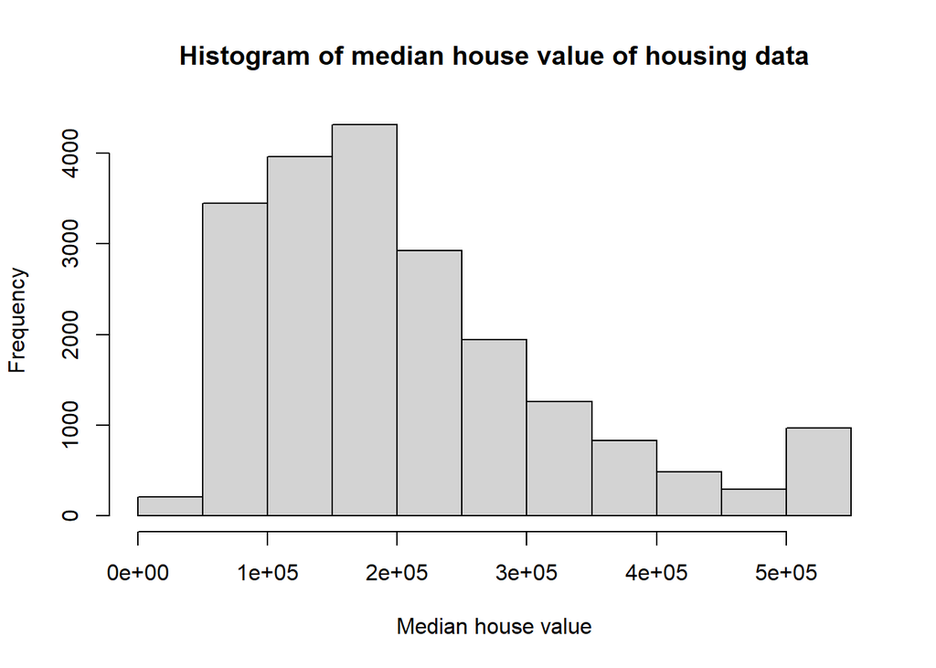

```r
hist(Housing$median_house_value, main = "Histogram of median house value of housing data",xlab = "Median house value")
```

*By seeing the above picture we can say Most of the values are less than mean hence it is positively skewed.

```
**BOXPLOT**
```

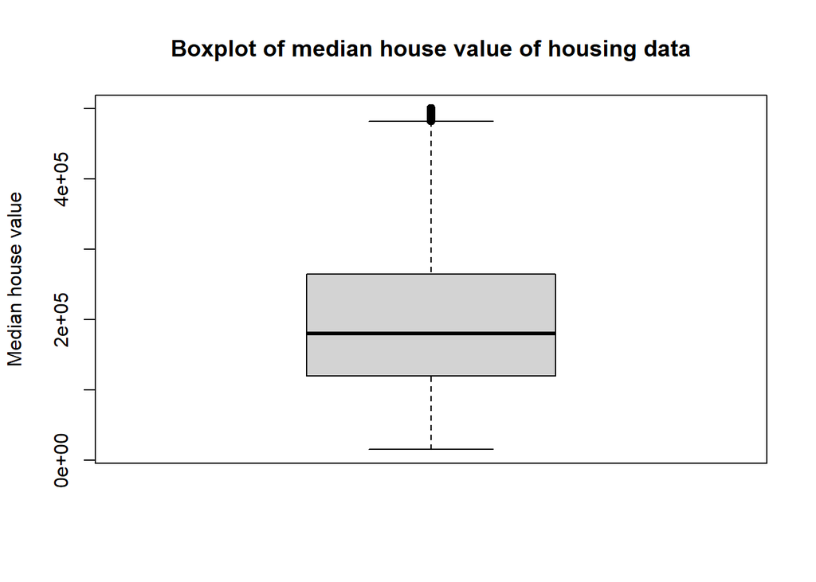

```r
boxplot(Housing$median_house_value, main="Boxplot of median house value of housing data",ylab= "Median house value")
```

**6)Use Q-Q plot to examine if the distribution of median_house_value is approximately normal?**

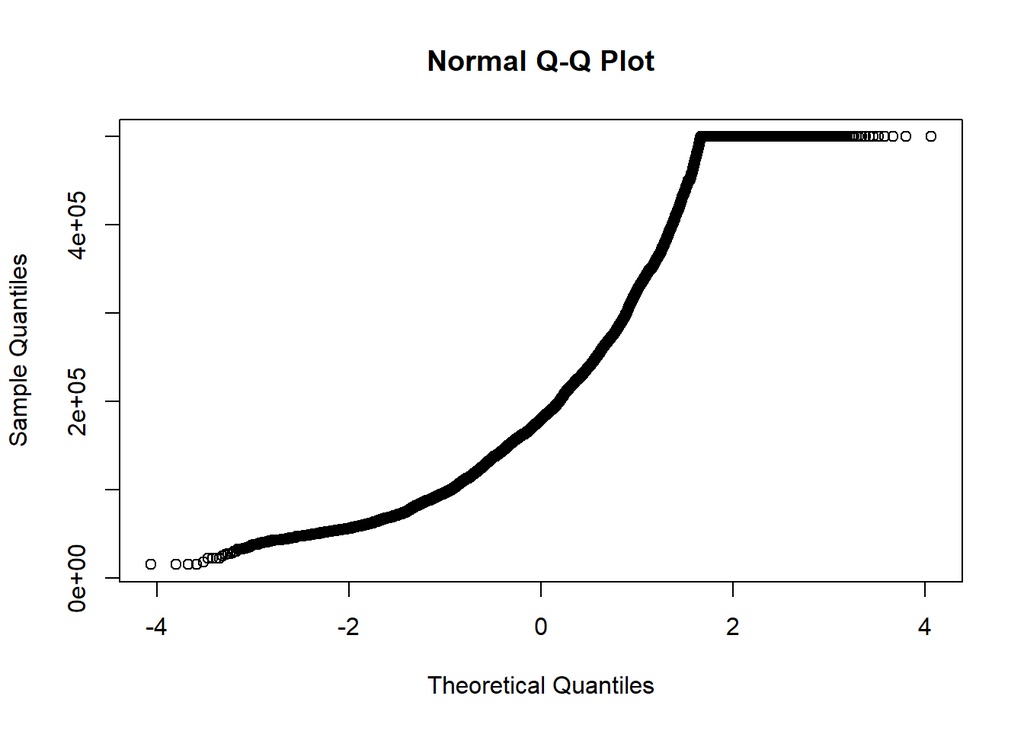

```r
qqnorm(Housing$median_house_value)
```

*By seeing the above graph we can say that it is not a linear line but it is of both curve at start and horizantal at end , so we say that it is not normal*

**7)Use IQR method to find outliers of the median_house_value attribute. How many outliers does this attribute have?**

```r
q<-Housing$median_house_value
Q<-IQR(q)
q1<-summary(q)[[2]]
q3<-summary(q)[[5]]
left<-q1-1.5*Q
right<-q3+1.5*Q
x <- q[q<left | q>right]
length(x)
```

```
## [1] 1071
```

**8)Does any of the numerical attributes have a positive/negative linear correlation with median_house_value? Use scatter plots and correlation matrix to answer this question**

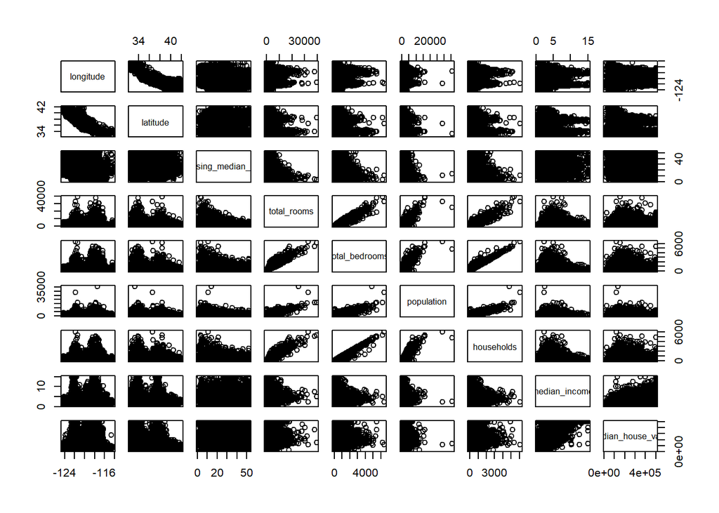

```r
numeric_veriable<-Housing[,c("longitude","latitude","housing_median_age","total_rooms","total_bedrooms","population","households","median_income","median_house_value")]

pairs(numeric_veriable)
```

```r
cor(numeric_veriable)
```

```
##                      longitude    latitude housing_median_age total_rooms
## longitude           1.00000000 -0.92466443        -0.10819681  0.04456798
## latitude           -0.92466443  1.00000000         0.01117267 -0.03609960
## housing_median_age -0.10819681  0.01117267         1.00000000 -0.36126220
## total_rooms         0.04456798 -0.03609960        -0.36126220  1.00000000
## total_bedrooms              NA          NA                 NA          NA
## population          0.09977322 -0.10878475        -0.29624424  0.85712597
## households          0.05531009 -0.07103543        -0.30291601  0.91848449
## median_income      -0.01517587 -0.07980913        -0.11903399  0.19804965
## median_house_value -0.04596662 -0.14416028         0.10562341  0.13415311
##                    total_bedrooms   population  households median_income
## longitude                      NA  0.099773223  0.05531009  -0.015175865
## latitude                       NA -0.108784747 -0.07103543  -0.079809127
## housing_median_age             NA -0.296244240 -0.30291601  -0.119033990
## total_rooms                    NA  0.857125973  0.91848449   0.198049645
## total_bedrooms                  1           NA          NA            NA
## population                     NA  1.000000000  0.90722227   0.004834346
## households                     NA  0.907222266  1.00000000   0.013033052
## median_income                  NA  0.004834346  0.01303305   1.000000000
## median_house_value             NA -0.024649679  0.06584265   0.688075208
##                    median_house_value
## longitude                 -0.04596662
## latitude                  -0.14416028
## housing_median_age         0.10562341
## total_rooms                0.13415311
## total_bedrooms                     NA
## population                -0.02464968
## households                 0.06584265
## median_income              0.68807521
## median_house_value         1.00000000
```

- by seeing the graph, we can say that it is linear line with increasing from x axis.so we can say that it is Postive linear corelation.*

**9)Is there a statistically significant difference between the mean of meadian house_valueacross different levels of ocean_proximity ? Use an appropriate plot and statistical test (with significance level alpha=0.01) to answer this question.**

```r
oneway.test(median_house_value~ocean_proximity, data=Housing)
```

```
##
##  One-way analysis of means (not assuming equal variances)
##
## data:  median_house_value and ocean_proximity
## F = 2079.3, num df = 4.000, denom df = 31.919, p-value < 2.2e-16
```

*From the oneway.test we can conclude that there is significant difference between the mean of median_house_value across different levels of ocean_proximity as p-value returned using oneway.test is less than alpha

**10)Use ifelse function to create a new factor variable “Is_Inland” which takesthe value “Yes” if the ocean_proximity is “Inland” and No” otherwise.**

```r
Is_Inland = factor(ifelse(Housing$ocean_proximity=="INLAND","YES","NO"))
table(Is_Inland)
```

```
## Is_Inland
##    NO   YES
## 14089  6551
```

**11)Use side by side box plot to visualize the relationship between “Is_Inland” and“median_house_value”. Is there a significant difference between the means of median_house_value for Inland vs not Inland houses? Use an appropriate statistical test to answer this question ( use significance level alpha=0.01)**

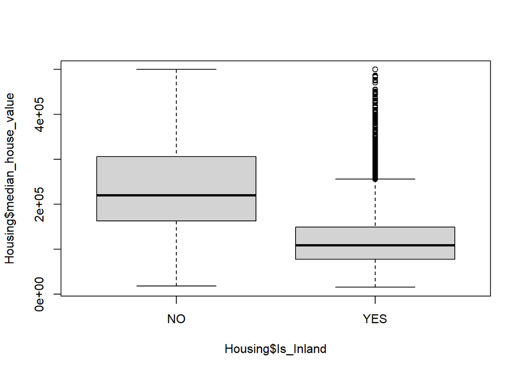

```r
Housing$Is_Inland = factor(ifelse(Housing$ocean_proximity=="INLAND","YES","NO"))
plot(Housing$median_house_value~Housing$Is_Inland)
```

```r
t.test(Housing$median_house_value~Housing$Is_Inland)
```

```
##
##  Welch Two Sample t-test
##
## data:  Housing$median_house_value by Housing$Is_Inland
## t = 93.704, df = 18987, p-value < 2.2e-16
## alternative hypothesis: true difference in means between group NO and group YES is not equal to 0
## 95 percent confidence interval:
##  117687.3 122716.0
## sample estimates:
##  mean in group NO mean in group YES
##          245007.0          124805.4
```

*From the above side by side boxplot and t.test we can conclude that there is significant difference between the means of median_house_value for Inland vs not Inland houses because p-value returned using t.test is less than alpha

##Heart Disease Dataset

**1)Open these files and examine the data in them. Note that the files do not have a header and the missing values are marked by “?” character. Each file contains the 14 attributes described here. Load each file to a dataframe ( remember to set na.string=”?” so that “?” is recognized as missing not a data value).**

```r
dfSwis<-read.csv("C:/Users/mmoku2/Downloads/processed.switzerland.data",na.strings = "?",header = FALSE)

dfHung<-read.csv("C:/Users/mmoku2/Downloads/processed.hungarian.data",na.strings = "?",header = FALSE)

dfClev<-read.csv("C:/Users/mmoku2/Downloads/processed.cleveland.data",na.strings = "?",header = FALSE)

dfVa<-read.csv("C:/Users/mmoku2/Downloads/processed.va.data",na.strings = "?",header = FALSE)
```

**2)Use rbind function to combine the four dataframes into one dataframe and manually set the column names using colnames function. The name of each column/attribute is described here.**

```r
MainDf<-rbind(dfSwis,dfClev,dfHung,dfVa)
str(MainDf)
```

```
## 'data.frame':    920 obs. of  14 variables:
##  $ V1 : num  32 34 35 36 38 38 38 38 38 38 ...
##  $ V2 : num  1 1 1 1 0 0 1 1 1 1 ...
##  $ V3 : num  1 4 4 4 4 4 3 3 4 4 ...
##  $ V4 : num  95 115 NA 110 105 110 100 115 135 150 ...
##  $ V5 : num  0 0 0 0 0 0 0 0 0 0 ...
##  $ V6 : num  NA NA NA NA NA 0 NA 0 NA NA ...
##  $ V7 : num  0 NA 0 0 0 0 0 0 0 0 ...
##  $ V8 : num  127 154 130 125 166 156 179 128 150 120 ...
##  $ V9 : num  0 0 1 1 0 0 0 1 0 1 ...
##  $ V10: num  0.7 0.2 NA 1 2.8 0 -1.1 0 0 NA ...
##  $ V11: num  1 1 NA 2 1 2 1 2 NA NA ...
##  $ V12: num  NA NA NA NA NA NA NA NA NA NA ...
##  $ V13: num  NA NA 7 6 NA 3 NA 7 3 3 ...
##  $ V14: int  1 1 3 1 2 1 0 1 2 1 ...
```

```r
n<-c("Age","Sex","Cp","Trestbps","Chol","Fbs","Restecg","Thalach","Exang","Oldpeak","Slope","Ca","Thal","Num")

colnames(MainDf)<-n

colnames(MainDf)
```

```
##  [1] "Age"      "Sex"      "Cp"       "Trestbps" "Chol"     "Fbs"
##  [7] "Restecg"  "Thalach"  "Exang"    "Oldpeak"  "Slope"    "Ca"
## [13] "Thal"     "Num"
```

**3)Explore the overall structure of the dataset. What percentage of rows have missing values in one or more attributes?**

```r
c<-is.na(MainDf)
mytable<-table(c)
mytable
```

```
## c
## FALSE  TRUE
## 11121  1759
```

```r
s<-sum(mytable)
s
```

```
## [1] 12880
```

```r
st<-sum(mytable[["TRUE"]])
st
```

```
## [1] 1759
```

```r
per<-(st/s)*100
per
```

```
## [1] 13.65683
```

```r
M<-is.na(MainDf)
colMeans(M)*100
```

```
##        Age        Sex         Cp   Trestbps       Chol        Fbs    Restecg
##  0.0000000  0.0000000  0.0000000  6.4130435  3.2608696  9.7826087  0.2173913
##    Thalach      Exang    Oldpeak      Slope         Ca       Thal        Num
##  5.9782609  5.9782609  6.7391304 33.5869565 66.4130435 52.8260870  0.0000000
```

**4)Read the data description carefully. Decide which attributes are categorical and convert them to “factor” using factor function ( set the “labels” option to give meaningful names/labels to each level)**

```r
MainDf$Sex<-factor(MainDf$Sex,levels =c("1","0"))
MainDf$Cp<-factor(MainDf$Cp,levels =c("1","2","3","4"))
MainDf$Fbs<-factor(MainDf$Fbs,levels =c("1","0"))
MainDf$Restecg<-factor(MainDf$Restecg,levels =c("0","1","2"))
MainDf$Exang<-factor(MainDf$Exang,levels =c("1","0"))
MainDf$Slope<-factor(MainDf$Slope,levels=c("1","2","3"))
MainDf$Thal<-factor(MainDf$Thal,levels=c("3","6","7"))

str(MainDf)
```

```
## 'data.frame':    920 obs. of  14 variables:
##  $ Age     : num  32 34 35 36 38 38 38 38 38 38 ...
##  $ Sex     : Factor w/ 2 levels "1","0": 1 1 1 1 2 2 1 1 1 1 ...
##  $ Cp      : Factor w/ 4 levels "1","2","3","4": 1 4 4 4 4 4 3 3 4 4 ...
##  $ Trestbps: num  95 115 NA 110 105 110 100 115 135 150 ...
##  $ Chol    : num  0 0 0 0 0 0 0 0 0 0 ...
##  $ Fbs     : Factor w/ 2 levels "1","0": NA NA NA NA NA 2 NA 2 NA NA ...
##  $ Restecg : Factor w/ 3 levels "0","1","2": 1 NA 1 1 1 1 1 1 1 1 ...
##  $ Thalach : num  127 154 130 125 166 156 179 128 150 120 ...
##  $ Exang   : Factor w/ 2 levels "1","0": 2 2 1 1 2 2 2 1 2 1 ...
##  $ Oldpeak : num  0.7 0.2 NA 1 2.8 0 -1.1 0 0 NA ...
##  $ Slope   : Factor w/ 3 levels "1","2","3": 1 1 NA 2 1 2 1 2 NA NA ...
##  $ Ca      : num  NA NA NA NA NA NA NA NA NA NA ...
##  $ Thal    : Factor w/ 3 levels "3","6","7": NA NA 3 2 NA 1 NA 3 1 1 ...
##  $ Num     : int  1 1 3 1 2 1 0 1 2 1 ...
```

**5)What is the median and mode of the age attribute**

```r
median(MainDf$Age)
```

```
## [1] 54
```

```r
summary(MainDf)
```

```
##       Age        Sex     Cp         Trestbps          Chol         Fbs
##  Min.   :28.00   1:726   1: 46   Min.   :  0.0   Min.   :  0.0   1   :138
##  1st Qu.:47.00   0:194   2:174   1st Qu.:120.0   1st Qu.:175.0   0   :692
##  Median :54.00           3:204   Median :130.0   Median :223.0   NA's: 90
##  Mean   :53.51           4:496   Mean   :132.1   Mean   :199.1
##  3rd Qu.:60.00                   3rd Qu.:140.0   3rd Qu.:268.0
##  Max.   :77.00                   Max.   :200.0   Max.   :603.0
##                                  NA's   :59      NA's   :30
##  Restecg       Thalach       Exang        Oldpeak         Slope
##  0   :551   Min.   : 60.0   1   :337   Min.   :-2.6000   1   :203
##  1   :179   1st Qu.:120.0   0   :528   1st Qu.: 0.0000   2   :345
##  2   :188   Median :140.0   NA's: 55   Median : 0.5000   3   : 63
##  NA's:  2   Mean   :137.5              Mean   : 0.8788   NA's:309
##             3rd Qu.:157.0              3rd Qu.: 1.5000
##             Max.   :202.0              Max.   : 6.2000
##             NA's   :55                 NA's   :62
##        Ca           Thal          Num
##  Min.   :0.0000   3   :196   Min.   :0.0000
##  1st Qu.:0.0000   6   : 46   1st Qu.:0.0000
##  Median :0.0000   7   :192   Median :1.0000
##  Mean   :0.6764   NA's:486   Mean   :0.9957
##  3rd Qu.:1.0000              3rd Qu.:2.0000
##  Max.   :3.0000              Max.   :4.0000
##  NA's   :611
```

```r
temp<-table(MainDf$Age)
x<-temp==max(temp)
names(which(x))
```

```
## [1] "54"
```

**6)Are female patients under-represented compared to male patients in this dataset?**

```r
mytable<-table(MainDf$Sex)
mytable
```

```
##
##   1   0
## 726 194
```

```r
s<-sum(mytable)
st<-sum(mytable[["0"]])
per<-(st/s)*100
per
```

```
## [1] 21.08696
```

**7)Use “ifelse” and “factor” functions to create a new factor variable (call it “diagnosis”) whichtakes the value “No” if column 14 has the value zero and “Yes” otherwise. Replace column 14 of your dataframe with this new variable.**

```r
MainDf$Diagnosis = factor(ifelse(MainDf$Num=="0","NO","YES"))
table(MainDf$Diagnosis)
```

```
##
##  NO YES
## 411 509
```

```r
MainDf['Num'] <- MainDf['Diagnosis']
str(MainDf)
```

```
## 'data.frame':    920 obs. of  15 variables:
##  $ Age      : num  32 34 35 36 38 38 38 38 38 38 ...
##  $ Sex      : Factor w/ 2 levels "1","0": 1 1 1 1 2 2 1 1 1 1 ...
##  $ Cp       : Factor w/ 4 levels "1","2","3","4": 1 4 4 4 4 4 3 3 4 4 ...
##  $ Trestbps : num  95 115 NA 110 105 110 100 115 135 150 ...
##  $ Chol     : num  0 0 0 0 0 0 0 0 0 0 ...
##  $ Fbs      : Factor w/ 2 levels "1","0": NA NA NA NA NA 2 NA 2 NA NA ...
##  $ Restecg  : Factor w/ 3 levels "0","1","2": 1 NA 1 1 1 1 1 1 1 1 ...
##  $ Thalach  : num  127 154 130 125 166 156 179 128 150 120 ...
##  $ Exang    : Factor w/ 2 levels "1","0": 2 2 1 1 2 2 2 1 2 1 ...
##  $ Oldpeak  : num  0.7 0.2 NA 1 2.8 0 -1.1 0 0 NA ...
##  $ Slope    : Factor w/ 3 levels "1","2","3": 1 1 NA 2 1 2 1 2 NA NA ...
##  $ Ca       : num  NA NA NA NA NA NA NA NA NA NA ...
##  $ Thal     : Factor w/ 3 levels "3","6","7": NA NA 3 2 NA 1 NA 3 1 1 ...
##  $ Num      : Factor w/ 2 levels "NO","YES": 2 2 2 2 2 2 1 2 2 2 ...
##  $ Diagnosis: Factor w/ 2 levels "NO","YES": 2 2 2 2 2 2 1 2 2 2 ...
```

**8)Explore the relationship between “diagnosis”variable and all other attributes in the dataset. Which variables are associated with “diagnosis” use appropriate plots and statistical tests to answer this question. (Note to get full credit for this question, you should use both an appropriate plot and an appropriate statistics test to examine the relationship between each of these variables and sentiment. You should also interpret each plot). Please refer to the lectures to see what type of statistical test and plot you need to use for bivariate analysis based on the type of variables**

*Categorical Vs Numerica* **Age~Diagnosis**

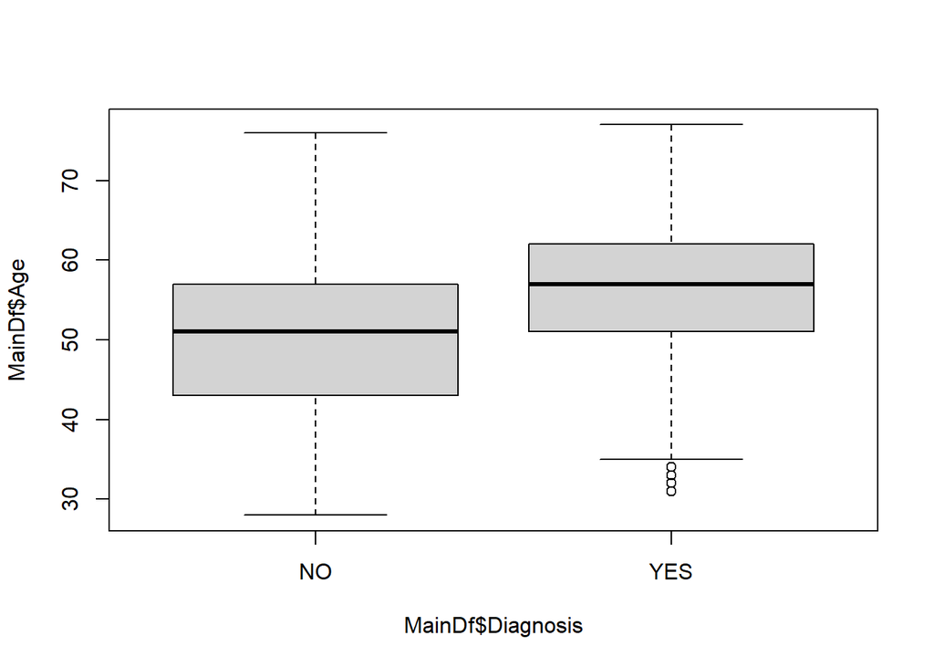

```r
plot(MainDf$Age~MainDf$Diagnosis)
```

```r
t.test(MainDf$Age~MainDf$Diagnosis)
```

```
##
##  Welch Two Sample t-test
##
## data:  MainDf$Age by MainDf$Diagnosis
## t = -8.8551, df = 845.86, p-value < 2.2e-16
## alternative hypothesis: true difference in means between group NO and group YES is not equal to 0
## 95 percent confidence interval:
##  -6.543537 -4.169039
## sample estimates:
##  mean in group NO mean in group YES
##          50.54745          55.90373
```

*Assumed significance value alpha=0.05,By above tests , p is less than alpha so we say that both are associated.

**Trestbps~Diagnosis**

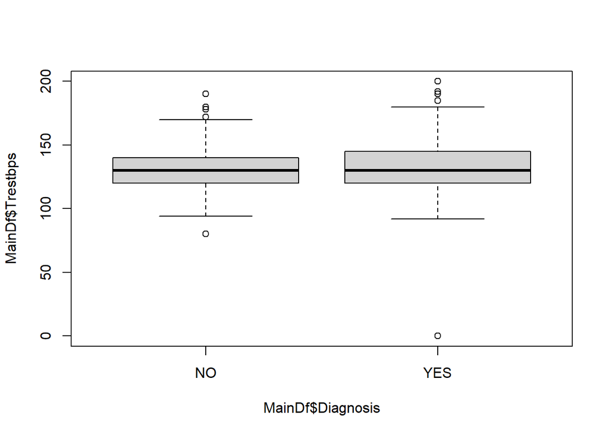

```r
plot(MainDf$Trestbps~MainDf$Diagnosis)
```

```r
t.test(MainDf$Trestbps~MainDf$Diagnosis)
```

```
##
##  Welch Two Sample t-test
##
## data:  MainDf$Trestbps by MainDf$Diagnosis
## t = -3.1878, df = 858.85, p-value = 0.001485
## alternative hypothesis: true difference in means between group NO and group YES is not equal to 0
## 95 percent confidence interval:
##  -6.56889 -1.56247
## sample estimates:
##  mean in group NO mean in group YES
##          129.9130          133.9787
```

*Assumed significance value alpha=0.5,By above tests , p is less than alpha so we say that both are associated.

**Chol~Diagnosis**

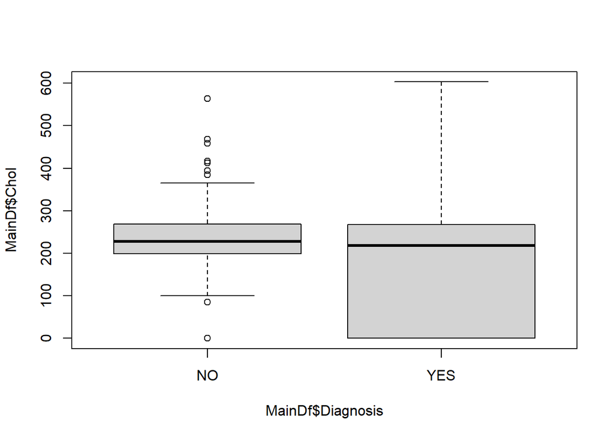

```r
plot(MainDf$Chol~MainDf$Diagnosis)
```

```r
t.test(MainDf$Chol~MainDf$Diagnosis)
```

```
##
##  Welch Two Sample t-test
##
## data:  MainDf$Chol by MainDf$Diagnosis
## t = 7.4756, df = 830.75, p-value = 1.951e-13
## alternative hypothesis: true difference in means between group NO and group YES is not equal to 0
## 95 percent confidence interval:
##  37.92323 64.92815
## sample estimates:
##  mean in group NO mean in group YES
##          227.9056          176.4799
```

**Thalach~Diagnosis**

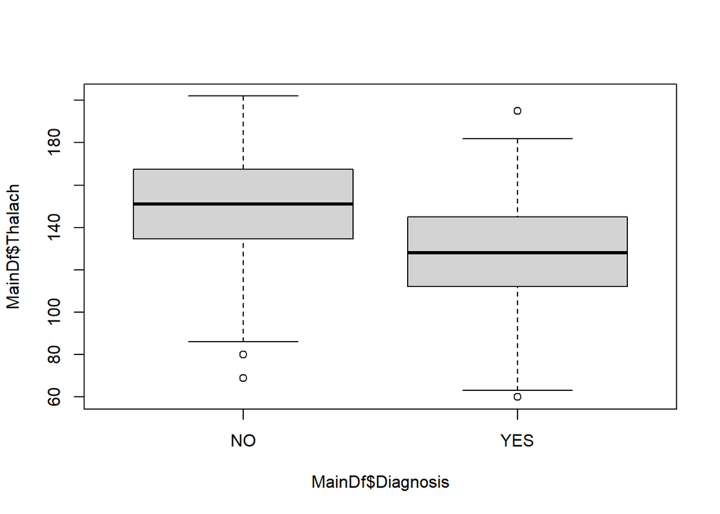

```r
plot(MainDf$Thalach~MainDf$Diagnosis)
```

```r
t.test(MainDf$Thalach~MainDf$Diagnosis)
```

```
##
##  Welch Two Sample t-test
##
## data:  MainDf$Thalach by MainDf$Diagnosis
## t = 12.633, df = 837.18, p-value < 2.2e-16
## alternative hypothesis: true difference in means between group NO and group YES is not equal to 0
## 95 percent confidence interval:
##  17.34784 23.72998
## sample estimates:
##  mean in group NO mean in group YES
##          148.8005          128.2616
```

**Ca~Diagnosis**

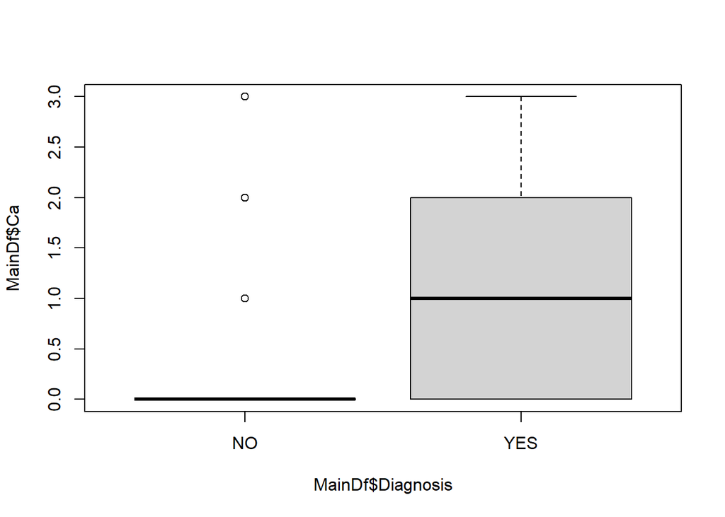

```r
plot(MainDf$Ca~MainDf$Diagnosis)
```

```r
t.test(MainDf$Ca~MainDf$Diagnosis)
```

```
##
##  Welch Two Sample t-test
##
## data:  MainDf$Ca by MainDf$Diagnosis
## t = -8.7091, df = 235.24, p-value = 5.508e-16
## alternative hypothesis: true difference in means between group NO and group YES is not equal to 0
## 95 percent confidence interval:
##  -1.0461515 -0.6601617
## sample estimates:
##  mean in group NO mean in group YES
##         0.2787879         1.1319444
```

**Caregorical Vs Categorical**

**Sex~Diagnosis**

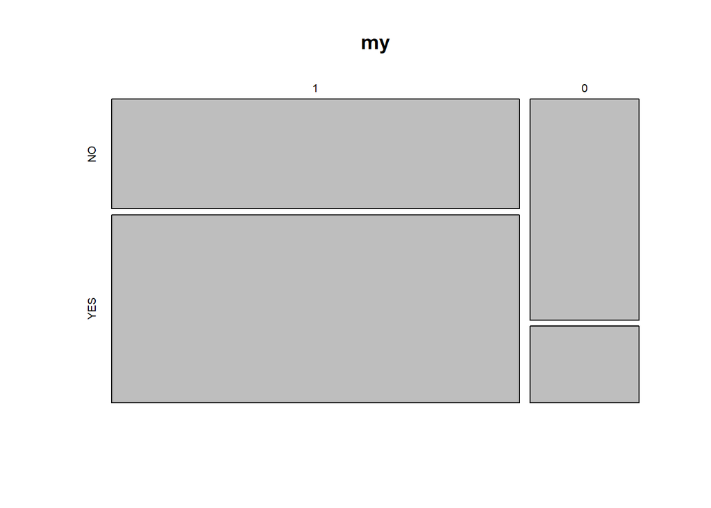

```r
my<-table(MainDf$Sex,MainDf$Diagnosis)
mosaicplot(my)
```

```r
chisq.test(my)
```

```
##
##  Pearson's Chi-squared test with Yates' continuity correction
##
## data:  my
## X-squared = 85.361, df = 1, p-value < 2.2e-16
```

**Cp~Diagnosis**

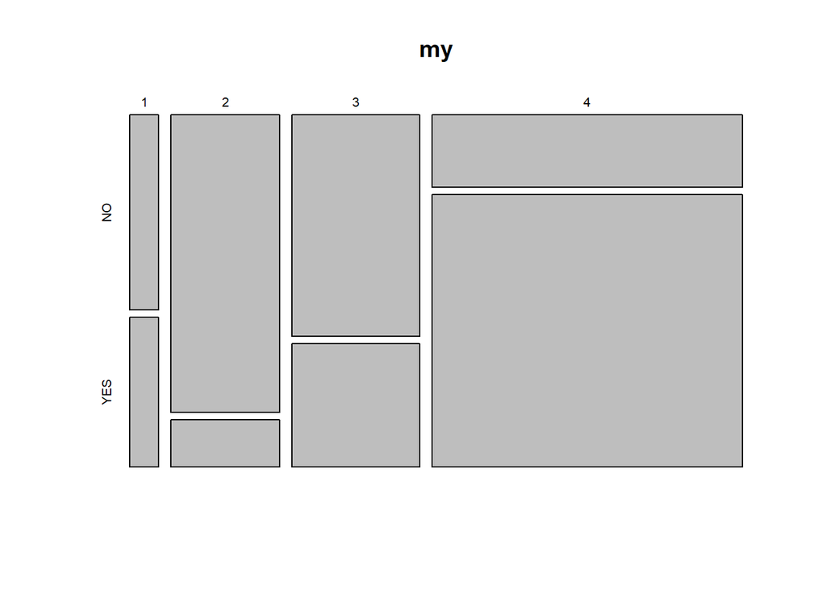

```r
my<-table(MainDf$Cp,MainDf$Diagnosis)
mosaicplot(my)
```

```r
chisq.test(my)
```

```
##
##  Pearson's Chi-squared test
##
## data:  my
## X-squared = 268.35, df = 3, p-value < 2.2e-16
```

**Fbs~Diagnosis**

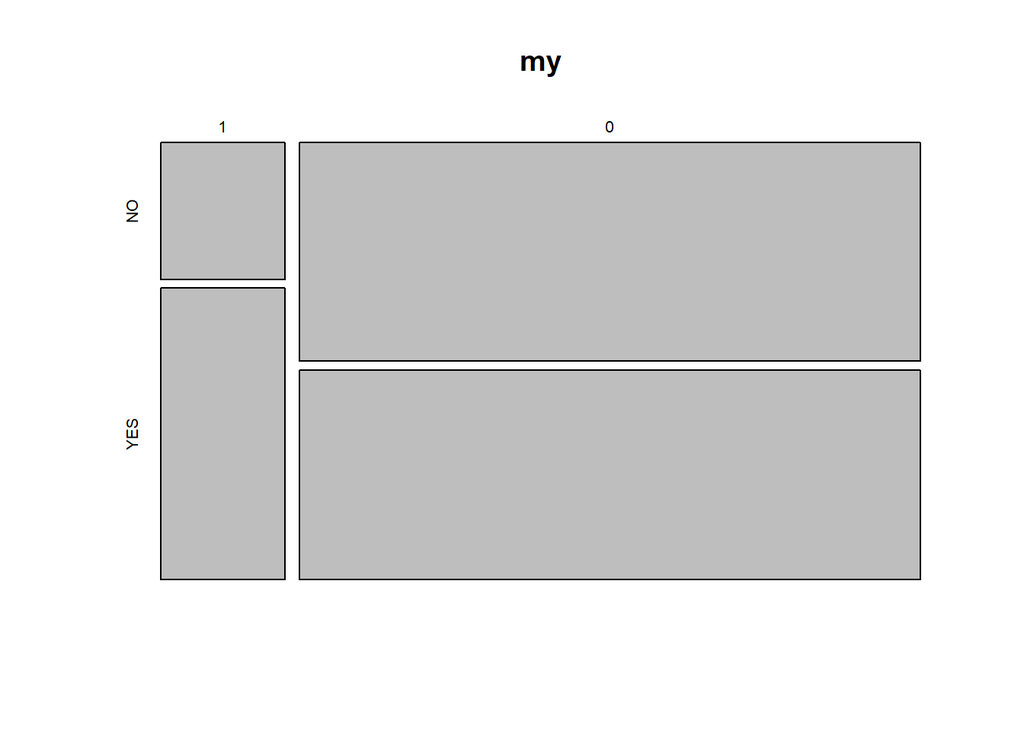

```r
my<-table(MainDf$Fbs,MainDf$Diagnosis)
mosaicplot(my)
```

```r
chisq.test(my)
```

```
##
##  Pearson's Chi-squared test with Yates' continuity correction
##
## data:  my
## X-squared = 16.112, df = 1, p-value = 5.972e-05
```

**Restecg~Diagnosis**

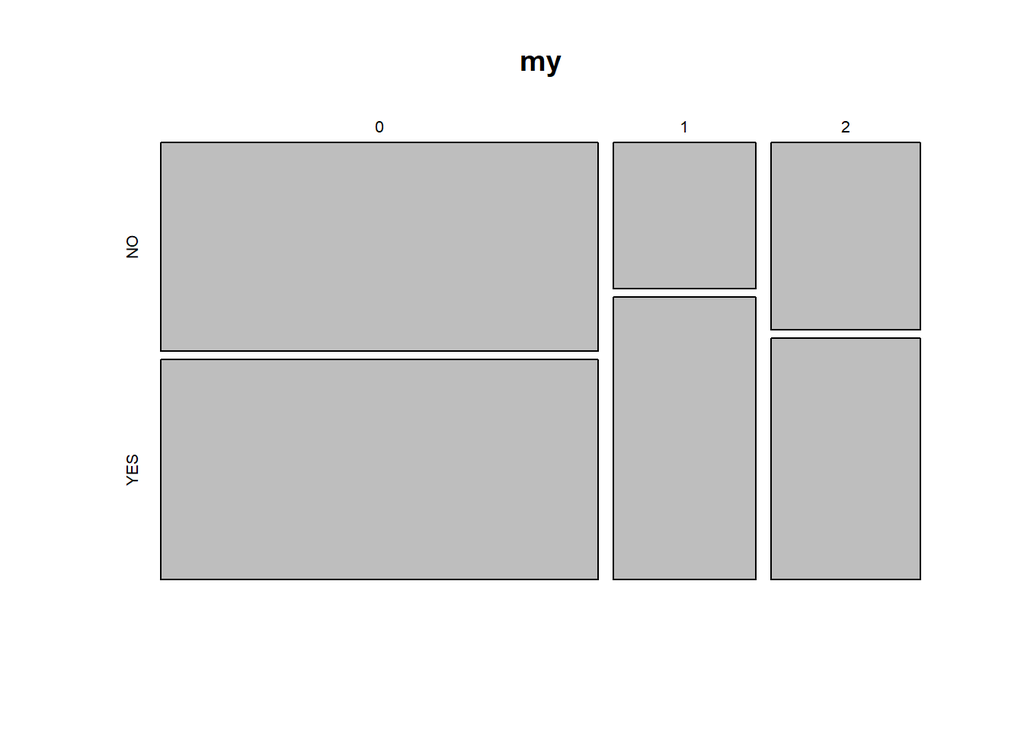

```r
my<-table(MainDf$Restecg,MainDf$Diagnosis)
mosaicplot(my)
```

```r
chisq.test(my)
```

```
##
##  Pearson's Chi-squared test
##
## data:  my
## X-squared = 11.712, df = 2, p-value = 0.002863
```

**Exang~Diagnosis**

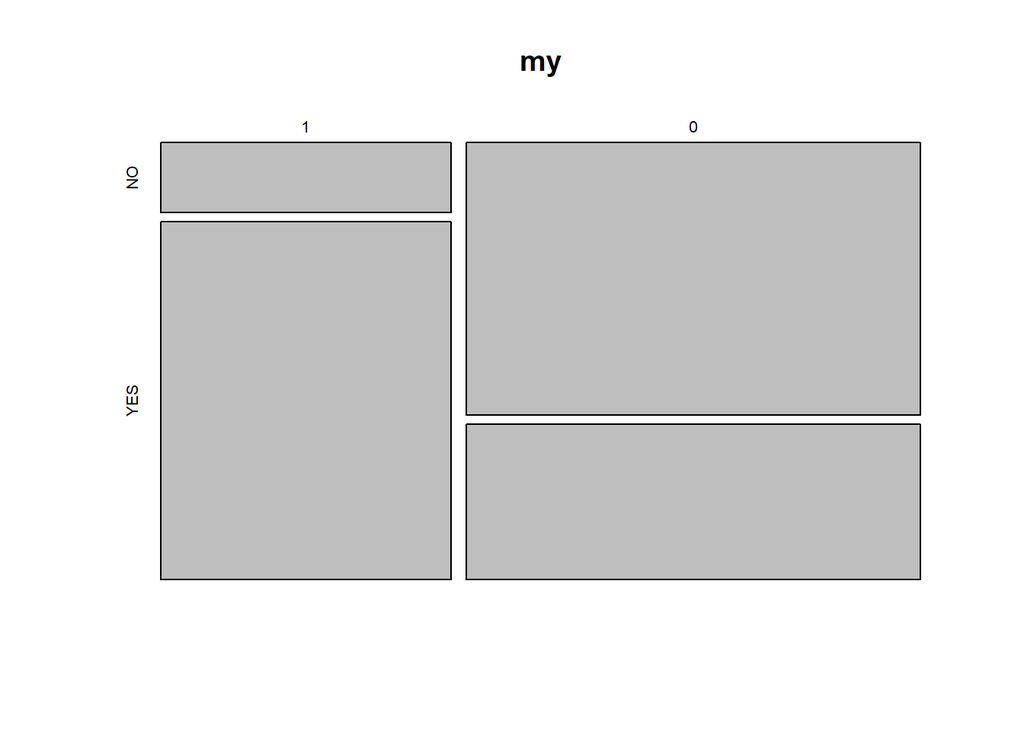

```r
my<-table(MainDf$Exang,MainDf$Diagnosis)
mosaicplot(my)
```

```r
chisq.test(my)
```

```
##
##  Pearson's Chi-squared test with Yates' continuity correction
##
## data:  my
## X-squared = 184.02, df = 1, p-value < 2.2e-16
```

**Slope~Diagnosis**

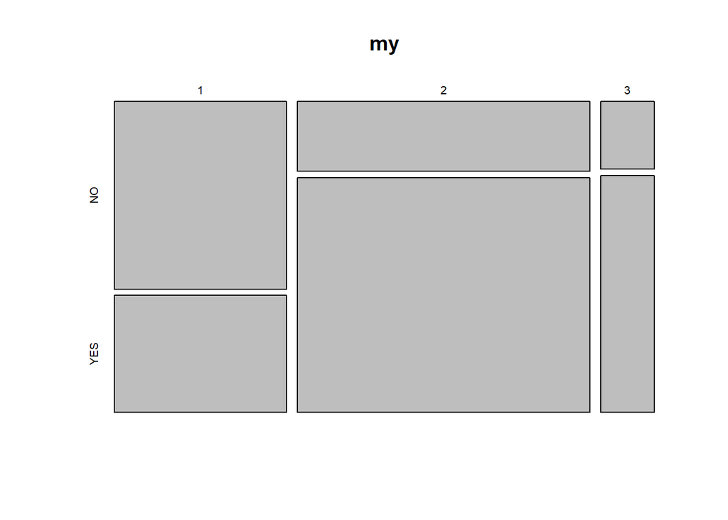

```r
my<-table(MainDf$Slope,MainDf$Diagnosis)
mosaicplot(my)
```

```r
chisq.test(my)
```

```
##
##  Pearson's Chi-squared test
##
## data:  my
## X-squared = 88.852, df = 2, p-value < 2.2e-16
```

**Thal~Diagnosis**

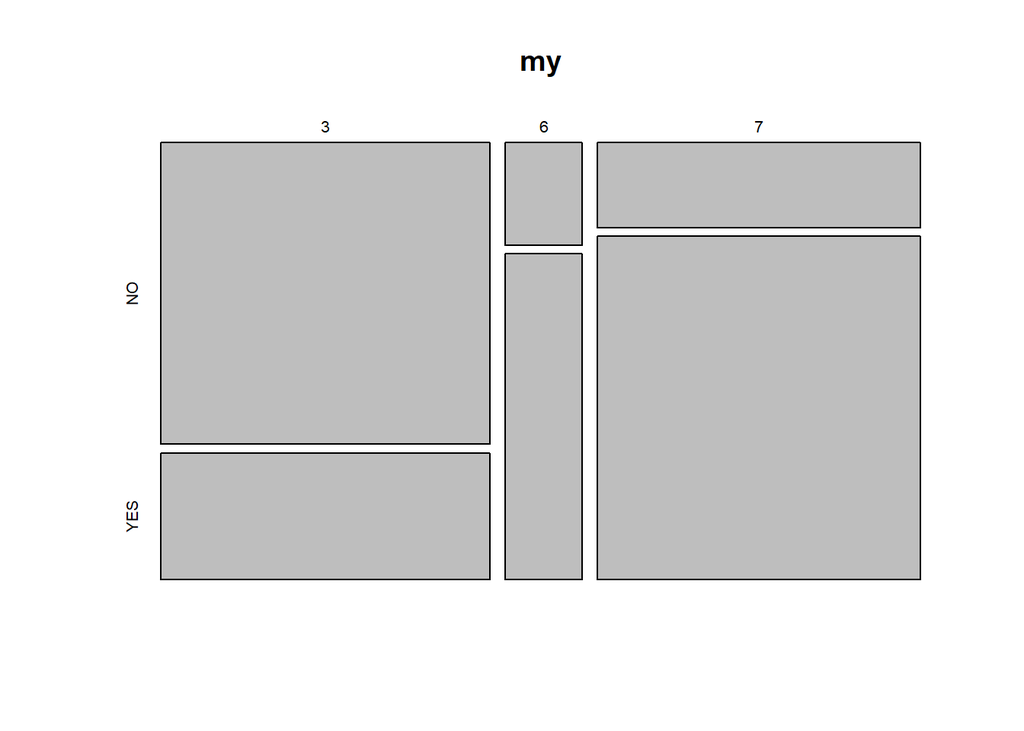

```r
my<-table(MainDf$Thal,MainDf$Diagnosis)
mosaicplot(my)
```

```r
chisq.test(my)
```

```
##
##  Pearson's Chi-squared test
##
## data:  my
## X-squared = 109.05, df = 2, p-value < 2.2e-16
```

*By seeing all the tests of Diagnosis with other Caterogical values(Sex,Thal,Slope,Cp,Exang,Resteg,Fbs) all are asscoited with diagnosis because p is less than alpha value(assumed value as 0.5)